# 21_bobbing_duck

## 21_bobbing_duck

#### Question

1. A mallard floats in a large ocean (in deep water far from shore). The mallard is not moving in [cardinal directions](https://en.wikipedia.org/wiki/Cardinal_direction), but the mallard is bobbing up and down as the [wind waves](https://en.wikipedia.org/wiki/Wind_wave) pass.

   In deep water, with a large fetch, when wind is consistently blowing at 11.5 meters per second, the waves will have the following (approximate) characteristics:
   - The wavelength equals 42.7 meters.
   - The wave height equals 1.99 meters.
   - The wave speed equals 6.66 meters/second.

   I’ve animated this below… somewhat to scale.

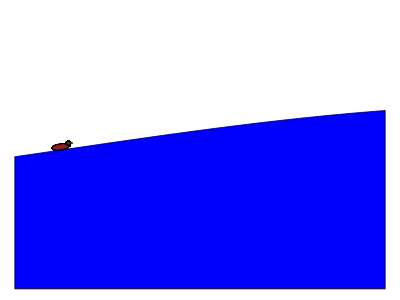

   What is the period (in seconds) of these waves? In other words, how much time does it take for the mallard to complete a cycle? The tolerance is $\pm 0.01$ seconds.

#### Question

2. A mallard floats in a large ocean (in deep water far from shore). The mallard is not moving in [cardinal directions](https://en.wikipedia.org/wiki/Cardinal_direction), but the mallard is bobbing up and down as the [wind waves](https://en.wikipedia.org/wiki/Wind_wave) pass.

   In deep water, with a large fetch, when wind is consistently blowing at 12.9 meters per second, the waves will have the following (approximate) characteristics:
   - The wave speed equals 7.45 meters/second.
   - The wave height equals 2.64 meters.
   - The wavelength equals 53.5 meters.

   I’ve animated this below… somewhat to scale.

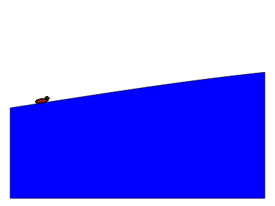

   What is the period (in seconds) of these waves? In other words, how much time does it take for the mallard to complete a cycle? The tolerance is $\pm 0.01$ seconds.

#### Question

3. A mallard floats in a large ocean (in deep water far from shore). The mallard is not moving in [cardinal directions](https://en.wikipedia.org/wiki/Cardinal_direction), but the mallard is bobbing up and down as the [wind waves](https://en.wikipedia.org/wiki/Wind_wave) pass.

   In deep water, with a large fetch, when wind is consistently blowing at 14.8 meters per second, the waves will have the following (approximate) characteristics:
   - The wavelength equals 70.1 meters.
   - The wave height equals 3.7 meters.
   - The wave speed equals 8.53 meters/second.

   I’ve animated this below… somewhat to scale.

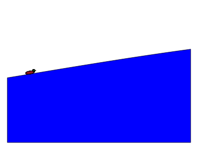

   What is the period (in seconds) of these waves? In other words, how much time does it take for the mallard to complete a cycle? The tolerance is $\pm 0.01$ seconds.

#### Question

4. A mallard floats in a large ocean (in deep water far from shore). The mallard is not moving in [cardinal directions](https://en.wikipedia.org/wiki/Cardinal_direction), but the mallard is bobbing up and down as the [wind waves](https://en.wikipedia.org/wiki/Wind_wave) pass.

   In deep water, with a large fetch, when wind is consistently blowing at 14.7 meters per second, the waves will have the following (approximate) characteristics:
   - The wavelength equals 69.5 meters.
   - The wave height equals 3.66 meters.
   - The wave speed equals 8.49 meters/second.

   I’ve animated this below… somewhat to scale.

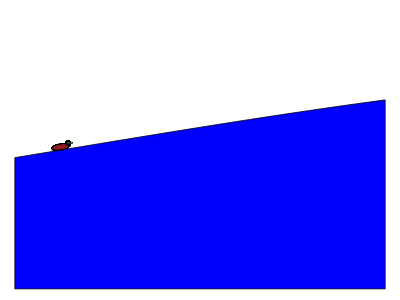

   What is the period (in seconds) of these waves? In other words, how much time does it take for the mallard to complete a cycle? The tolerance is $\pm 0.01$ seconds.

#### Question

5. A mallard floats in a large ocean (in deep water far from shore). The mallard is not moving in [cardinal directions](https://en.wikipedia.org/wiki/Cardinal_direction), but the mallard is bobbing up and down as the [wind waves](https://en.wikipedia.org/wiki/Wind_wave) pass.

   In deep water, with a large fetch, when wind is consistently blowing at 8.13 meters per second, the waves will have the following (approximate) characteristics:
   - The wave speed equals 4.7 meters/second.
   - The wave height equals 0.831 meters.
   - The wavelength equals 21.2 meters.

   I’ve animated this below… somewhat to scale.

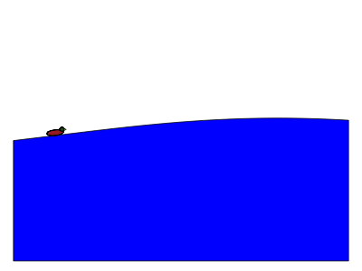

   What is the period (in seconds) of these waves? In other words, how much time does it take for the mallard to complete a cycle? The tolerance is $\pm 0.01$ seconds.

#### Question

6. A mallard floats in a large ocean (in deep water far from shore). The mallard is not moving in [cardinal directions](https://en.wikipedia.org/wiki/Cardinal_direction), but the mallard is bobbing up and down as the [wind waves](https://en.wikipedia.org/wiki/Wind_wave) pass.

   In deep water, with a large fetch, when wind is consistently blowing at 11.8 meters per second, the waves will have the following (approximate) characteristics:
   - The wavelength equals 44.8 meters.
   - The wave speed equals 6.82 meters/second.
   - The wave height equals 2.11 meters.

   I’ve animated this below… somewhat to scale.

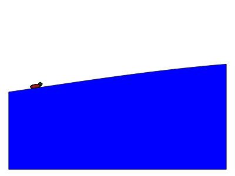

   What is the period (in seconds) of these waves? In other words, how much time does it take for the mallard to complete a cycle? The tolerance is $\pm 0.01$ seconds.

#### Question

7. A mallard floats in a large ocean (in deep water far from shore). The mallard is not moving in [cardinal directions](https://en.wikipedia.org/wiki/Cardinal_direction), but the mallard is bobbing up and down as the [wind waves](https://en.wikipedia.org/wiki/Wind_wave) pass.

   In deep water, with a large fetch, when wind is consistently blowing at 9.78 meters per second, the waves will have the following (approximate) characteristics:
   - The wave speed equals 5.65 meters/second.
   - The wave height equals 1.32 meters.
   - The wavelength equals 30.8 meters.

   I’ve animated this below… somewhat to scale.

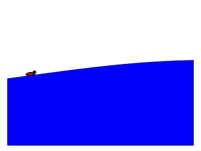

   What is the period (in seconds) of these waves? In other words, how much time does it take for the mallard to complete a cycle? The tolerance is $\pm 0.01$ seconds.

#### Question

8. A mallard floats in a large ocean (in deep water far from shore). The mallard is not moving in [cardinal directions](https://en.wikipedia.org/wiki/Cardinal_direction), but the mallard is bobbing up and down as the [wind waves](https://en.wikipedia.org/wiki/Wind_wave) pass.

   In deep water, with a large fetch, when wind is consistently blowing at 13.5 meters per second, the waves will have the following (approximate) characteristics:
   - The wave speed equals 7.83 meters/second.
   - The wavelength equals 59 meters.
   - The wave height equals 2.98 meters.

   I’ve animated this below… somewhat to scale.

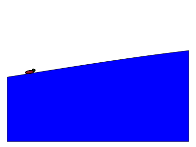

   What is the period (in seconds) of these waves? In other words, how much time does it take for the mallard to complete a cycle? The tolerance is $\pm 0.01$ seconds.